# Support Vector Machines

Support Vector Machines (SVMs) are powerful and versatile supervised learning models used primarily for classification tasks, although they can also be applied to regression and outlier detection. SVMs work by finding the optimal hyperplane that separates data points of different classes with the maximum margin. The idea is to not just classify correctly, but to do so with confidence — maximizing the distance from the nearest data points, known as support vectors.

SVMs can handle both linearly separable and non-linearly separable data. For non-linear cases, they use a technique called the kernel trick (e.g., RBF kernel) to project data into a higher-dimensional space where a linear separator might exist.

### Use Cases

Used for any binary or multi-class classification problem where clear separation between classes is valuable. This includes

- Predicting customer response. E.g., ad clicks, email opens, purchase
- Email spam detection (spam vs. not spam)
- Image classification (e.g., handwritten digit recognition)
- Sentiment analysis (positive vs. negative reviews)
- Bioinformatics (e.g., disease classification based on gene expression)

### Strengths

- Effective in high-dimensional spaces
- Robust to overfitting in small datasets with proper tuning
- Supports non-linear classification via kernels

### Weakenesses

- Training can be slow for large datasets
- Results are less interpretable than tree or linear models
- Requires tuning of kernel and regularization parameters
- Not suitable for overlapping or noisy class boundaries

## Overview

This note will examine the use of Support Vector Machines for classification of two-class and multi-class problems using linear and non-linear support vector machines. We will also look at an example of the use of support vector machines for a regression problem.

## Linear SVM

### Data

The dataset describes sepal and petal length and width for three flowers

- sepal_length
- sepal_width
- petal_length
- petal_width
- target: 0 (setosa), 1 (versicolor), 2 (virginica)

```python
from sklearn.datasets import load_iris
iris = load_iris()
X_raw = iris.data
y = iris.target
```

```python
import numpy as np
import pandas as pd
pd.DataFrame(X_raw,columns=iris.feature_names).assign(flower = y).head()
```

|  | sepal length (cm) | sepal width (cm) | petal length (cm) | petal width (cm) | flower |
| --- | --- | --- | --- | --- | --- |
| 0 | 5.1 | 3.5 | 1.4 | 0.2 | 0 |
| 1 | 4.9 | 3.0 | 1.4 | 0.2 | 0 |
| 2 | 4.7 | 3.2 | 1.3 | 0.2 | 0 |
| 3 | 4.6 | 3.1 | 1.5 | 0.2 | 0 |
| 4 | 5.0 | 3.6 | 1.4 | 0.2 | 0 |

### Split

```python
from sklearn.model_selection import train_test_split
X_train_raw, X_test_raw, y_train, y_test = train_test_split(X_raw,y,test_size = 0.3,random_state=617)
```

### Scale

Support vector machines is sensitive to scale of features, so it is common practice to standardize features before use in SVM

```python
from sklearn.preprocessing import StandardScaler
scale = StandardScaler()
scale.fit(X_train_raw)
X_train = scale.transform(X_train_raw)
X_test = scale.transform(X_test_raw)
```

### Model

- Construct SVM using class LinearSVC
- Regularization hyperparameter C is at its default value of 1

```python
from sklearn.svm import LinearSVC
svm = LinearSVC(C = 1,random_state=617)
#svm = SVC(kernel = 'linear', C = 1,random_state=617)
svm.fit(X_train,y_train)
```

```
LinearSVC(C=1, random_state=617)
```

### Predict

- Examine predictions
- Unlike logistic regression, SVM does not have a predict_proba() method to extract class probabilities

```python
pred_train = svm.predict(X_train)
pred_test =  svm.predict(X_test)
pred_train
```

```
array([1, 1, 1, 0, 1, 2, 0, 2, 2, 1, 2, 0, 0, 1, 2, 1, 1, 0, 0, 1, 1, 0,
       0, 0, 2, 2, 1, 0, 0, 0, 2, 2, 0, 2, 0, 0, 0, 2, 0, 2, 0, 2, 1, 2,
       1, 0, 0, 2, 0, 2, 0, 2, 1, 0, 1, 0, 2, 1, 1, 0, 2, 2, 1, 1, 2, 0,
       1, 1, 2, 1, 1, 2, 1, 1, 2, 2, 2, 0, 0, 2, 1, 0, 0, 1, 1, 2, 1, 2,
       2, 2, 2, 0, 1, 1, 2, 0, 2, 1, 0, 1, 2, 2, 0, 0, 0])
```

### Decision Function

- Measures the signed distance between each instance and the decision boundary
- Used to make predictions
- Here are predictions and distances for the first six flowers in train

```python
svm.predict(X_train)[0:6]
```

```
array([1, 1, 1, 0, 1, 2])
```

```python
svm.decision_function(X_train)[0:6,:]
```

```
array([[-1.20478531, -0.31821828, -1.05494006],
       [-2.03849001,  0.34496742, -0.05449767],
       [-2.36511564,  0.65547709,  0.29482181],
       [ 1.42338684, -0.78125666, -5.63607496],
       [-0.87328097, -0.24187038, -1.41121369],
       [-2.72540022, -0.10282018,  2.00361562]])
```

### Evaluate Predictions

```python
from sklearn.metrics import accuracy_score
accuracy_score(y_train, pred_train)
accuracy_score(y_test, pred_test)
```

```
0.9111111111111111
```

### Process

- In most predictive models, all observations affect fit.
- However, for SVM, only the Support Vectors have an effect on fit.
- This is illustrated by the plots below.
- Since it is hard to visualize multidimensional space, plots are based on an SVM with only sepal length and sepal width.
- Also, LinearSVC does not have a support method so we are using the class SVC with a “linear” kernel
- The plot represents each row in the data and the decision boundaries

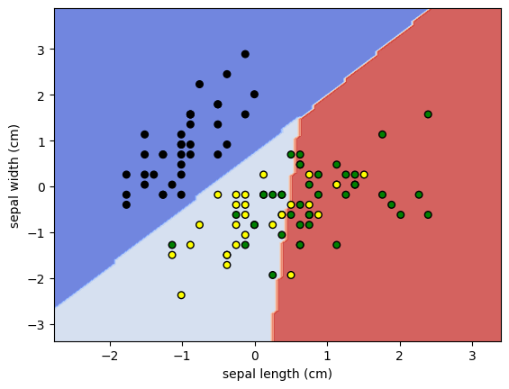

```python
iris = load_iris()
X_raw = iris.data[:,:2]
y = iris.target
X_train_raw, X_test_raw, y_train, y_test = train_test_split(X_raw,y,test_size = 0.3,random_state=617)

scale = StandardScaler()
scale.fit(X_train_raw)
X_train = scale.transform(X_train_raw)
X_test = scale.transform(X_test_raw)

from sklearn.svm import SVC
svm = SVC(kernel = 'linear', C = 1,random_state=617)
#svm = LinearSVC(C = 1,random_state=617)
svm.fit(X_train,y_train)


from sklearn.inspection import DecisionBoundaryDisplay
import matplotlib.pyplot as plt
from matplotlib.colors import ListedColormap
DecisionBoundaryDisplay.from_estimator(svm,
                                       X_train,
                                       response_method="predict",
                                       cmap=plt.cm.coolwarm,
                                       alpha=0.8,
                                       xlabel=iris.feature_names[0],
                                       ylabel=iris.feature_names[1])
plt.scatter(X_train[:, 0],
            X_train[:, 1],
            c = y_train,
#            cmap=plt.cm.coolwarm,
            cmap = ListedColormap(['black', 'yellow','green']),
            s=30,
            edgecolors="k")
plt.show()
```

#### Plot with support vectors

- In a SVM, only support vectors have an effect on fit
- Support vectors listed below are marked on the plot

```python
svm.support_
```

```
array([ 17,  29,  32,  38,  50,   0,   1,   4,   9,  13,  15,  16,  19,
        26,  30,  41,  44,  52,  54,  58,  67,  69,  70,  72,  73,  80,
        83,  84,  86,  89,  93,  97,  99,   2,   7,   8,  10,  14,  24,
        25,  31,  37,  39,  42,  43,  47,  49,  51,  56,  64,  71,  74,
        75,  76,  87,  90,  94, 100], dtype=int32)
```

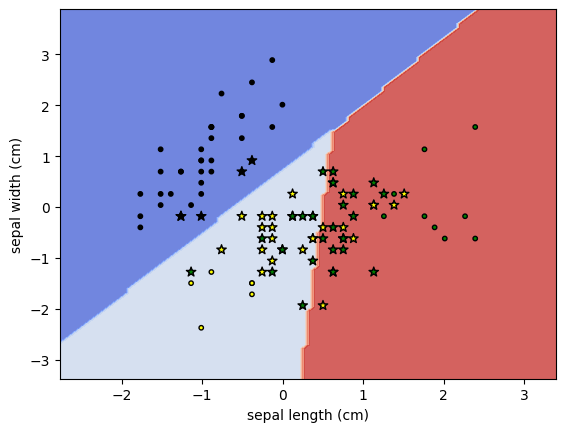

```python
DecisionBoundaryDisplay.from_estimator(svm,
                                       X_train,
                                       response_method="predict",
                                       cmap=plt.cm.coolwarm,
                                       alpha=0.8,
                                       xlabel=iris.feature_names[0],
                                       ylabel=iris.feature_names[1])
plt.scatter(X_train[:, 0],
            X_train[:, 1],
            c = y_train,
#            cmap=plt.cm.coolwarm,
            cmap = ListedColormap(['black', 'yellow','green']),
            s=10,
            edgecolors="k")
plt.scatter(X_train[svm.support_, 0],
            X_train[svm.support_, 1],
            c = y_train[svm.support_],
#            cmap=plt.cm.coolwarm,
            cmap = ListedColormap(['black', 'yellow','green']),
            s=50,
            marker = '*',
            edgecolors="k")
plt.show()
```

#### Plot with only support vectors

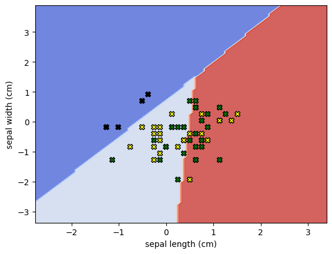

```python
DecisionBoundaryDisplay.from_estimator(svm,
                                       X_train,
                                       response_method="predict",
                                       cmap=plt.cm.coolwarm,
                                       alpha=0.8,
                                       xlabel=iris.feature_names[0],
                                       ylabel=iris.feature_names[1])

plt.scatter(X_train[svm.support_, 0],
            X_train[svm.support_, 1],
            c = y_train[svm.support_],
#            cmap=plt.cm.coolwarm,
            cmap = ListedColormap(['black', 'yellow','green']),
            s=40,
            marker = 'X',
            edgecolors="k")
plt.show()
```

The number of support vectors depends on the regularization hyperparameter C.

```python
num_sv = []
C = []
for x in [1,10,25]:
    svm = SVC(C = x, kernel = 'linear')
    svm.fit(X_train, y_train)
    num_sv.append(len(svm.support_))
    C.append(x)
pd.DataFrame({'Value of C':C, 'Number of Support Vectors':num_sv})
```

|  | Value of C | Number of Support Vectors |
| --- | --- | --- |
| 0 | 1 | 58 |
| 1 | 10 | 52 |
| 2 | 25 | 52 |

## Non-Linear SVM

- Although linear SVM classifiers are efficient and often work surprisingly well, they do not work with all datasets.
- One solution to add polynomial features. However, in practice with complex datasets, one may have to create a very large number of polynomial features.
- Kernel SVMs implement feature transformations in a computationally efficient way. This is done by what known as the kernel trick.
- This can be implemented using kernel = ‘rbf’ in the SVC class.
- For this first run, we are using default values of hyperparameters, C, gamma and coef0.
- This is illustrated below with the iris dataset. Since the data preparation process was discussed above, only the code for these steps is included.

### Model

```python
iris = load_iris()
X_raw = iris.data
y = iris.target
X_train_raw, X_test_raw, y_train, y_test = train_test_split(X_raw,y,test_size = 0.3,random_state=617)

scale = StandardScaler()
scale.fit(X_train_raw)
X_train = scale.transform(X_train_raw)
X_test = scale.transform(X_test_raw)

from sklearn.svm import SVC
svm = SVC(kernel = 'rbf', C = 1, random_state=617)
svm.fit(X_train,y_train)
```

```
SVC(C=1, random_state=617)
```

### Predict

```python
pred_train = svm.predict(X_train)
pred_test =  svm.predict(X_test)
pred_train
```

```
array([1, 2, 2, 0, 1, 2, 0, 2, 2, 1, 2, 0, 0, 1, 2, 1, 1, 0, 0, 1, 1, 0,
       0, 0, 2, 2, 1, 0, 0, 0, 2, 2, 0, 2, 0, 0, 0, 2, 0, 2, 0, 1, 2, 2,
       1, 0, 0, 2, 0, 2, 0, 2, 1, 0, 1, 0, 2, 1, 1, 0, 2, 2, 1, 1, 2, 0,
       1, 1, 2, 1, 1, 2, 1, 1, 2, 1, 2, 0, 0, 2, 1, 0, 0, 1, 1, 2, 1, 2,
       2, 1, 2, 0, 1, 1, 2, 0, 2, 1, 0, 1, 2, 2, 0, 0, 0])
```

### Evaluate

```python
from sklearn.metrics import accuracy_score
print('Train accuracy: ', accuracy_score(y_train, pred_train))
print('Test accuracy:  ', accuracy_score(y_test, pred_test) )
```

```
Train accuracy:  0.9714285714285714
Test accuracy:   0.9777777777777777
```

### LinearSVC vs. SVC

- LinearSVC class is based on the liblinear library, which implements an optimized algorithm for linear SVM. It does not support the kernel trick, but it scales almost linearly with the number of training instances and the number of features. Its training time complexity is roughly O(m × n).
- The SVC class is based on the libsvm library, which implements an algorithm that supports the kernel trick. The training time complexity is usually between O(m2 × n) and O(m3 × n). Unfortunately, this means that it gets dreadfully slow when the number of training instances gets large (e.g., hundreds of thousands of instances), so this algorithm is best for small or medium-sized nonlinear training sets.
- So, if the data is large but can be fit with a linear classifier use LinearSVC. For non-linear relationships, use SVC.

## Tuning Hyperparameters

- Kernel SVMs have a set of hyperparameters that can control fit
- The gamma hyperparameter affects smoothness of decision boundaries. Small gamma produces smooth decision boundaries while large gamma produce complex boundaries.
- Not surprisingly, large gammas also overfit the data. This is illustrated below.

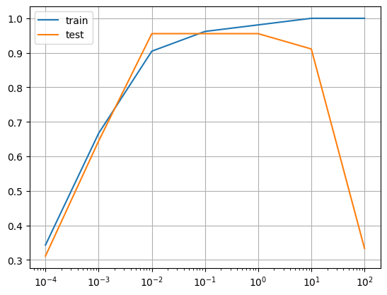

```python
perf_train = []
perf_test = []
gamma_values = [1e-4,1e-3,1e-2,1e-1,1, 1e1, 1e2]
for gamma_value in gamma_values:
    svc = SVC(gamma=gamma_value, random_state=617)
    svc.fit(X_train, y_train)
    perf_train.append(svc.score(X_train, y_train))
    perf_test.append(svc.score(X_test, y_test))
plt.semilogx(gamma_values, perf_train, gamma_values, perf_test)
plt.legend(("train", "test"))
plt.grid()
plt.show()
```

### Tuning gamma

We will tune gamma by examining 10-fold cross validation error for a set of values of gamma.

```python
from sklearn.model_selection import GridSearchCV
svc = SVC()
parameter_values = {'gamma': [1e-4,1e-3,1e-2,1e-1,1, 1e1]}
grid_search = GridSearchCV(svc,parameter_values, cv=10)
grid_search.fit(X_train, y_train)
```

```
GridSearchCV(cv=10, estimator=SVC(),
             param_grid={'gamma': [0.0001, 0.001, 0.01, 0.1, 1, 10.0]})
```

```python
print(grid_search.best_estimator_, grid_search.best_score_)
```

```
SVC(gamma=0.1) 0.9618181818181817
```

```python
print(grid_search.score(X_train, y_train))
print(grid_search.score(X_test, y_test))
```

```
0.9619047619047619
0.9555555555555556
```

### Tune C

In addition, to gamma, let us tune regularization paramater C as well.

```python
svc = SVC(random_state=617)
parameter_values = {'C':[0.1,1,10],
                    'gamma': [1e-4,1e-3,1e-2,1e-1,1, 1e1]}
grid_search = GridSearchCV(svc,parameter_values,cv=10)
grid_search.fit(X_train, y_train)
```

```
GridSearchCV(cv=10, estimator=SVC(random_state=617),
             param_grid={'C': [0.1, 1, 10],
                         'gamma': [0.0001, 0.001, 0.01, 0.1, 1, 10.0]})
```

```python
print(grid_search.best_estimator_, grid_search.best_score_)
```

```
SVC(C=10, gamma=0.01, random_state=617) 0.9718181818181819
```

```python
print(grid_search.score(X_train, y_train))
print(grid_search.score(X_test, y_test))
```

```
0.9714285714285714
0.9555555555555556
```

## SVM with Clicks Data

This dataset describes user interactions with online advertisements for a digital marketing platform. It includes demographic, behavioral, and contextual features for 2000 users, along with whether each user clicked on an ad. The goal is to predict whether a person clicked on an ad.

Variable Description

- click: Whether the user clicked on the ad. 1 = Clicked, 0 = Did not click
- age: Age of the user in years
- gender: Gender of the user. 1 = Male, 2 = Female
- device: Device used to access the site. 1 = Mobile, 2 = Desktop, 3 = Tablet
- browser: Browser used to access the site 1 = Chrome, 2 = Safari, 3 = Firefox, 4 = Edge, 5 = Other
- time_on_site: Time (in seconds) spent on site before ad was shown
- pages_visited: Number of pages visited before ad was shown
- ad_position: Position where the ad appeared on the webpage. 1 = Top, 2 = Side, 3 = Bottom
- ad_type: Format of the ad shown. 1 = Banner, 2 = Video, 3 = Popup, 4 = Native
- is_weekend: Whether the ad impression occurred on a weekend. 1 = Weekend, 0 = Weekday
- user_logged_in: Whether the user was logged in when the ad was shown. 1 = Logged in, 0 = Anonymous
- past_click_rate: Historical average click-through rate for the user
- ad_relevance_score: Score from 1 to 10 indicating how relevant the ad is to the user profile

```python
clicks = pd.read_csv('clicks.csv')
clicks.head()
```

|  | click | age | gender | device | browser | time_on_site | pages_visited | ad_position | ad_type | is_weekend | user_logged_in | past_click_rate | ad_relevance_score |
| --- | --- | --- | --- | --- | --- | --- | --- | --- | --- | --- | --- | --- | --- |
| 0 | 0 | 50 | 2 | 2 | 1 | 211 | 1 | 3 | 4 | 1 | 1 | 0.069 | 7 |
| 1 | 0 | 57 | 1 | 1 | 3 | 251 | 4 | 2 | 3 | 0 | 1 | 0.043 | 6 |
| 2 | 1 | 68 | 1 | 1 | 2 | 222 | 2 | 2 | 1 | 0 | 1 | 0.073 | 9 |
| 3 | 0 | 30 | 2 | 2 | 1 | 206 | 2 | 1 | 1 | 0 | 1 | 0.147 | 4 |
| 4 | 0 | 60 | 2 | 1 | 2 | 183 | 6 | 2 | 3 | 0 | 1 | 0.183 | 5 |

```python
X = clicks.drop(['click'], axis=1)
y = clicks.click
```

### Split

```python
from sklearn.model_selection import train_test_split
X_train_raw, X_test_raw, y_train, y_test = train_test_split(X,y, train_size=0.7,random_state=617)
```

### Scale

```python
from sklearn.preprocessing import StandardScaler
scale = StandardScaler()
scale.fit(X_train_raw)
X_train = scale.transform(X_train_raw)
X_test = scale.transform(X_test_raw)
```

### Linear SVM

```python
from sklearn.svm import SVC
svm = SVC(kernel = 'linear', C = 1, random_state=617)
svm.fit(X_train, y_train)
```

```
SVC(C=1, kernel='linear', random_state=617)
```

#### Evaluate

```python
svm.score(X_train, y_train)
```

```
0.7485714285714286
```

```python
svm.score(X_test, y_test)
```

```
0.6966666666666667
```

### Non-Linear SVM

```python
from sklearn.svm import SVC
svm = SVC(kernel = 'rbf', random_state=617)
svm.fit(X_train, y_train)
```

```
SVC(random_state=617)
```

```python
svm.score(X_train, y_train)
```

```
0.79
```

```python
svm.score(X_test, y_test)
```

```
0.7116666666666667
```

### Tune gamma and C

```python
C = [1e-2,1e-1,1,1e1,1e2,1e3,1e4,1e5]
gamma = [1e-4,1e-3, 1e-2, 1e-1, 1, 1e1, 1e2, 1e3, 1e4]
parameter_values = {'C':C,
                    'gamma':gamma}
svm = SVC(random_state=617)
grid_search = GridSearchCV(svm, parameter_values,cv=5, n_jobs = -1)
grid_search.fit(X_train, y_train)
```

```
GridSearchCV(cv=5, estimator=SVC(random_state=617), n_jobs=-1,
             param_grid={'C': [0.01, 0.1, 1, 10.0, 100.0, 1000.0, 10000.0,
                               100000.0],
                         'gamma': [0.0001, 0.001, 0.01, 0.1, 1, 10.0, 100.0,
                                   1000.0, 10000.0]})
```

```python
print(grid_search.best_estimator_, grid_search.best_score_)
```

```
SVC(C=1000.0, gamma=0.0001, random_state=617) 0.7414285714285714
```

```python
print(grid_search.score(X_train, y_train))
print(grid_search.score(X_test, y_test))
```

```
0.7471428571428571
0.7
```

## SVM with Wine Data: Classification

Let us now attempt to classify wines as being high quality or low quality using a support vector classifier. The dataset we will use contains a set of White Wines characterized by chemical properties measured on eleven variables.

- fixed acidity
- volatile acidity
- citric acid
- residual sugar
- chlorides
- free sulfur dioxide
- total sulfur dioxide
- density
- pH
- sulphates
- alcohol

The quality of each wine is evaluated by sensory tests by wine experts. We will split wine quality using the mean.

### Read and Split Data

```python
wine = pd.read_csv('winequality-white.csv',sep=';')
X = wine.drop(['quality'], axis=1)
y = (wine.quality>wine.quality.mean()).astype('int')
X_train_raw, X_test_raw, y_train, y_test = train_test_split(X,y,test_size=0.3, random_state=617)
```

```python
from sklearn.preprocessing import StandardScaler
scale = StandardScaler()
X_train = scale.fit_transform(X_train_raw)
X_test = scale.fit_transform(X_test_raw)
```

### Linear SVM

Run a Linear Classifier using default values for hyperparameters

```python
from sklearn.svm import SVC
svm = SVC(kernel='linear', random_state=617)
svm.fit(X_train, y_train)
print(svm.score(X_train, y_train))
print(svm.score(X_test, y_test))
```

```
0.748541423570595
0.7510204081632653
```

### Non-Linear SVM

Run a Radial Basis Function Classifier using default values for hyperparameters

```python
from sklearn.svm import SVC
svc = SVC(kernel='rbf', random_state=617)
svc.fit(X_train, y_train)
print(svc.score(X_train, y_train))
print(svc.score(X_test, y_test))
```

```
0.8060093348891482
0.7850340136054422
```

### Tune Model Hyperparameters

```python
C = [1e-2,1e-1,1,1e1,1e2,1e3,1e4,1e5]
gamma = [1e-4,1e-3, 1e-2, 1e-1, 1, 1e1, 1e2, 1e3, 1e4]
parameter_values = {'C':C,
                    'gamma':gamma}
svc_tune = SVC(random_state=617)
grid_search = GridSearchCV(svc_tune, parameter_values,cv=5, n_jobs = -1)
grid_search.fit(X_train, y_train)
```

```
GridSearchCV(cv=5, estimator=SVC(random_state=617), n_jobs=-1,
             param_grid={'C': [0.01, 0.1, 1, 10.0, 100.0, 1000.0, 10000.0,
                               100000.0],
                         'gamma': [0.0001, 0.001, 0.01, 0.1, 1, 10.0, 100.0,
                                   1000.0, 10000.0]})
```

```python
print(grid_search.best_estimator_, grid_search.best_score_)
```

```
SVC(C=100.0, gamma=1, random_state=617) 0.7829618437573151
```

```python
print(grid_search.score(X_train, y_train))
print(grid_search.score(X_test, y_test))
```

```
1.0
0.7986394557823129
```

## SVM with Wine Data. Regression

To use SVMs for regression instead of classification, the trick is to tweak the objective: instead of trying to fit the largest possible street between two classes while limiting margin violations, SVM regression tries to fit as many instances as possible on the street while limiting margin violations (i.e., instances off the street).

The dataset we will use contains a set of White Wines characterized by chemical properties measured on eleven variables. The outcome variable we will use is quality.

- fixed acidity
- volatile acidity
- citric acid
- residual sugar
- chlorides
- free sulfur dioxide
- total sulfur dioxide
- density
- pH
- sulphates
- alcohol

```python
wine = pd.read_csv('winequality-white.csv',sep=';')
X = wine.drop(['quality'], axis=1)
y = wine.quality
X_train_raw, X_test_raw, y_train, y_test = train_test_split(X,y,test_size=0.3, random_state=617)
```

```python
from sklearn.preprocessing import StandardScaler
scale = StandardScaler()
X_train = scale.fit_transform(X_train_raw)
X_test = scale.fit_transform(X_test_raw)
```

### Non-Linear SVM

```python
from sklearn.svm import SVR
svm = SVR(kernel='rbf')
svm.fit(X_train, y_train)
pred_train = svm.predict(X_train)
pred_test = svm.predict(X_test)
```

```python
from sklearn.metrics import root_mean_squared_error
print('Train RMSE: ', root_mean_squared_error(y_train, pred_train))
print('Test RMSE:  ', root_mean_squared_error(y_test, pred_test))
```

```
Train RMSE:  0.6359967614439671
Test RMSE:   0.6609535072278201
```

### Tune Model Hyperparameters

```python
C = [1e-2,1e-1,1,1e1,1e2,1e3]
gamma = [1e-2, 1e-1, 1, 1e1, 1e2]
parameter_values = {'C':C,
                    'gamma':gamma}
svr_tune = SVR()
grid_search = GridSearchCV(svr_tune, parameter_values,cv=5, n_jobs = -1)
grid_search.fit(X_train, y_train)
```

```
GridSearchCV(cv=5, estimator=SVR(), n_jobs=-1,
             param_grid={'C': [0.01, 0.1, 1, 10.0, 100.0, 1000.0],
                         'gamma': [0.01, 0.1, 1, 10.0, 100.0]})
```

```python
print(grid_search.best_estimator_, grid_search.best_score_)
```

```
SVR(C=1, gamma=0.1) 0.3769931852587788
```

```python
pred_train = grid_search.predict(X_train)
pred_test = grid_search.predict(X_test)

from sklearn.metrics import root_mean_squared_error
print('Train RMSE: ', root_mean_squared_error(y_train, pred_train))
print('Test RMSE:  ', root_mean_squared_error(y_test, pred_test))
```

```
Train RMSE:  0.6281056459980318
Test RMSE:   0.6588453250550446
```

## Summary

We examined the use of Support Vector Machines for classification of two-class and multi-class problems using linear and non-linear support vector machines. We also looked at an example of the use of support vector machines for a regression problem.

```python
import platform
from IPython.display import display, HTML
import matplotlib
import sklearn as sklearn_complete
text = ('This file was generated using Python ' + platform.python_version() +\
      ' on a ' + platform.platform() + \
      ' system with Pandas ' + pd.__version__ + \
      ', Numpy ' + np.__version__ + \
      ', Matplotlib ' + matplotlib.__version__ + \
      ', Scikit-Learn ' + sklearn_complete.__version__ )

html = f"""
<hr style="border: 0; height: 1px; background: lightgray;" />
<p style="font-size: x-small; color: #555;">{text}</p>
"""

display(HTML(html))
```

This file was generated using Python 3.13.5 on a Windows-10-10.0.19045-SP0 system with Pandas 2.3.0, Numpy 2.3.1, Matplotlib 3.10.3, Scikit-Learn 1.7.1